JUNGHYUN YANG

# 데이터 마이닝 프로젝트

Jul 14, 2022 • 40 min read

### 목차

- 인구데이터기반소득예측경진대회
- 데이터 전처리
  - 데이터 가져오기
  - 결측치
- EDA
  - 상관관계 분석
    - 범주형 상관관계 분석
    - 수치형 상관관계 분석
    - 필요없는 변수 제거
  - 수치형 변수
    - age
    - education.num
    - capital.gain
    - capital.loss
    - hours.per.week
    - sex
  - 범주형 변수
    - 변수 고유값 확인
    - workclass
    - marital.status
    - occupation
    - relationship
- 모델링
  - 원핫인코딩
  - pycaret
  - submission
- 결론
  - summary
  - 활용가능
  - 한계
  - 향후계획

# 인구 데이터 기반 소득 예측경진대회

- 다양한 인구 데이터 바탕으로 소득이 5만달러 이하인지 초과인지 분류하는 대회.
- 분류 해야할 클래스는 5만달러 이하인지 초과인지 수입(target)을 총 두가지로 분류하는 대회.

대회 링크: https://dacon.io/competitions/official/235892/overview/description

다양한 공모전 중 머신러닝 관련 공모전에 참여하고 싶었고, Basic 공모전이라 모델링까지 내가 해볼 수 있을 것 같아 이 공모전을 선택하였다.  
또, 소득을 예측하기 위해 필요한 변수들 또한 한글 데이터로 어렵지 않게 구성되어있었으며, 어떠한 변수들이 소득에 영향을 주는 지 궁금하였다.

# 기본설정

```
id : 샘플 아이디
age : 나이
workclass : 일 유형
fnlwgt : CPS(Current Population Survey) 가중치
education : 교육수준
education.num : 교육수준 번호
marital.status : 결혼 상태
occupation : 직업
relationship : 가족관계
race : 인종
sex : 성별
capital.gain : 자본 이익
capital.loss : 자본 손실
hours.per.week : 주당 근무시간
native.country : 본 국적
target : 소득
`
```

```python
from google.colab import drive
drive.mount('/content/drive')
```

먼저 pycaret과 markupsafe을 설치 후 런타임 재시작을 해야 pycaret이 돌아감

```python
!pip install pycaret
```

[output not shown]

[output cut: 36 more lines]

[output not shown]

```python
!pip install markupsafe==2.0.1
```

[output not shown]

```python
import matplotlib.pyplot as plt
from pandas.plotting import scatter_matrix
import seaborn as sns
import platform
# 그래프 폰트 설정
# Window
if platform.system() == 'Windows':
    plt.rc('font', family='Malgun Gothic')
elif platform.system() == 'Darwin': # Mac
    plt.rc('font', family='AppleGothic')
else: #linux
    plt.rc('font', family='NanumGothic')

# 그래프에 마이너스 표시가 되도록 변경
plt.rcParams['axes.unicode_minus'] = False

# 파이썬 ≥3.5 필수
import sys
assert sys.version_info >= (3, 5)

# 사이킷런 ≥0.20 필수
# 여러가지 머신러닝 모델을 가지고 있는 라이브러리 *가장 많이 사용*
import sklearn
# 공통 모듈 임포트
import numpy as np
import os
import pandas as pd
from sklearn.model_selection import train_test_split

# 깔끔한 그래프 출력을 위해
plt.rcParams['font.family'] = 'NanumGothic'
%matplotlib inline
import matplotlib as mpl
import matplotlib.pyplot as plt
mpl.rc('axes', labelsize=14)
mpl.rc('xtick', labelsize=12)
mpl.rc('ytick', labelsize=12)
```

# 데이터 전처리

## 데이터 가져오기

```python
cd '/content/drive/MyDrive/소득예측'
```

```
/content/drive/MyDrive/소득예측
```

```python
train = pd.read_csv('train.csv')
test = pd.read_csv('test.csv')
submission = pd.read_csv('sample_submission.csv')
```

```python
print(train.shape, test.shape)
```

```
(17480, 16) (15081, 15)
```

```python
del train['education']
del test['education']
```

## 결측치

```python
train.isnull().sum()
# workclass, occupation, native.country 에 결측값이 존재한다.
```

```
id                   0
age                  0
workclass         1836
fnlwgt               0
education.num        0
marital.status       0
occupation        1843
relationship         0
race                 0
sex                  0
capital.gain         0
capital.loss         0
hours.per.week       0
native.country     583
target               0
dtype: int64
```

```python
train.info()
```

```
<class 'pandas.core.frame.DataFrame'>
RangeIndex: 17480 entries, 0 to 17479
Data columns (total 15 columns):
 #   Column          Non-Null Count  Dtype
---  ------          --------------  -----
 0   id              17480 non-null  int64
 1   age             17480 non-null  int64
 2   workclass       15644 non-null  object
 3   fnlwgt          17480 non-null  int64
 4   education.num   17480 non-null  int64
 5   marital.status  17480 non-null  object
 6   occupation      15637 non-null  object
 7   relationship    17480 non-null  object
 8   race            17480 non-null  object
 9   sex             17480 non-null  object
 10  capital.gain    17480 non-null  int64
 11  capital.loss    17480 non-null  int64
 12  hours.per.week  17480 non-null  int64
 13  native.country  16897 non-null  object
 14  target          17480 non-null  int64
dtypes: int64(8), object(7)
memory usage: 2.0+ MB
```

```python
train = train.dropna(axis=0)
```

# EDA

## 상관관계 분석

**수치형 자료**

```
'id','age', 'fnlwgt', 'education.num','capital.gain', 'capital.loss', 'hours.per.week', 'target'
```

### 범주형 상관관계 분석

```python
train_label_encoder = train.copy()
train_label_encoder
```

|  | id | age | workclass | fnlwgt | education.num | marital.status | occupation | relationship | race | sex | capital.gain | capital.loss | hours.per.week | native.country | target |
| --- | --- | --- | --- | --- | --- | --- | --- | --- | --- | --- | --- | --- | --- | --- | --- |
| 0 | 0 | 32 | Private | 309513 | 12 | Married-civ-spouse | Craft-repair | Husband | White | Male | 0 | 0 | 40 | United-States | 0 |
| 1 | 1 | 33 | Private | 205469 | 10 | Married-civ-spouse | Exec-managerial | Husband | White | Male | 0 | 0 | 40 | United-States | 1 |
| 2 | 2 | 46 | Private | 149949 | 10 | Married-civ-spouse | Craft-repair | Husband | White | Male | 0 | 0 | 40 | United-States | 0 |
| 3 | 3 | 23 | Private | 193090 | 13 | Never-married | Adm-clerical | Own-child | White | Female | 0 | 0 | 30 | United-States | 0 |
| 4 | 4 | 55 | Private | 60193 | 9 | Divorced | Adm-clerical | Not-in-family | White | Female | 0 | 0 | 40 | United-States | 0 |
| ... | ... | ... | ... | ... | ... | ... | ... | ... | ... | ... | ... | ... | ... | ... | ... |
| 15076 | 15076 | 35 | Private | 337286 | 14 | Never-married | Exec-managerial | Not-in-family | Asian-Pac-Islander | Male | 0 | 0 | 40 | United-States | 0 |
| 15077 | 15077 | 36 | Private | 182074 | 10 | Divorced | Adm-clerical | Not-in-family | White | Male | 0 | 0 | 45 | United-States | 0 |
| 15078 | 15078 | 50 | Self-emp-inc | 175070 | 15 | Married-civ-spouse | Prof-specialty | Husband | White | Male | 0 | 0 | 45 | United-States | 1 |
| 15079 | 15079 | 39 | Private | 202937 | 10 | Divorced | Tech-support | Not-in-family | White | Female | 0 | 0 | 40 | Poland | 0 |
| 15080 | 15080 | 33 | Private | 96245 | 12 | Married-civ-spouse | Prof-specialty | Husband | White | Male | 0 | 0 | 50 | United-States | 0 |

15081 rows × 15 columns

label encoder

```python
# 또, label encoding을 사용하면 분석 결과가 안좋아질 수 있으므로 복제하여 train_label_encoder 만든 뒤 상관관계분석을한다.
from sklearn.preprocessing import LabelEncoder

le = LabelEncoder()
train_label_encoder['workclass'] = le.fit_transform(train['workclass'])
train_label_encoder['marital.status'] = le.fit_transform(train['marital.status'])
train_label_encoder['occupation'] = le.fit_transform(train['occupation'])
train_label_encoder['relationship'] = le.fit_transform(train['relationship'])
train_label_encoder['race'] = le.fit_transform(train['race'])
train_label_encoder['sex'] = le.fit_transform(train['sex'])
train_label_encoder['native.country'] = le.fit_transform(train['native.country'])
```

```python
train_label_encoder.head()
```

|  | id | age | workclass | fnlwgt | education.num | marital.status | occupation | relationship | race | sex | capital.gain | capital.loss | hours.per.week | native.country | target |
| --- | --- | --- | --- | --- | --- | --- | --- | --- | --- | --- | --- | --- | --- | --- | --- |
| 0 | 0 | 32 | 2 | 309513 | 12 | 2 | 2 | 0 | 4 | 1 | 0 | 0 | 40 | 38 | 0 |
| 1 | 1 | 33 | 2 | 205469 | 10 | 2 | 3 | 0 | 4 | 1 | 0 | 0 | 40 | 38 | 1 |
| 2 | 2 | 46 | 2 | 149949 | 10 | 2 | 2 | 0 | 4 | 1 | 0 | 0 | 40 | 38 | 0 |
| 3 | 3 | 23 | 2 | 193090 | 13 | 4 | 0 | 3 | 4 | 0 | 0 | 0 | 30 | 38 | 0 |
| 4 | 4 | 55 | 2 | 60193 | 9 | 0 | 0 | 1 | 4 | 0 | 0 | 0 | 40 | 38 | 0 |

```python
corr_matrix = train_label_encoder.corr()
corr_matrix["target"].sort_values(ascending=False)
```

```
target            1.000000
education.num     0.341073
age               0.242283
hours.per.week    0.237383
capital.gain      0.221003
sex               0.216109
capital.loss      0.153660
race              0.079966
occupation        0.047896
native.country    0.030942
workclass         0.024025
id               -0.003228
fnlwgt           -0.005028
marital.status   -0.194685
relationship     -0.249029
Name: target, dtype: float64
```

[figure not shown]

```python
sns.heatmap(corr_matrix, cmap='Blues',annot=True)
sns.set(rc = {'figure.figsize':(20,20)})
```

### 수치형 상관관계 분석

변수가 너무 많으면 시각화를 해도 결과를 한눈에 보기에 어렵기 때문에 범주형 변수들은 따로 copy데이터를 만들어 label_encoder를 진행한 뒤 시각화하였고, 수치형 변수도 따로 상관관계 분석 및 시각화를 해주었다.

```python
corr_matrix = train.corr()
corr_matrix["target"].sort_values(ascending=False)
```

```
target            1.000000
education.num     0.341073
age               0.242283
hours.per.week    0.237383
capital.gain      0.221003
capital.loss      0.153660
id               -0.003228
fnlwgt           -0.005028
Name: target, dtype: float64
```

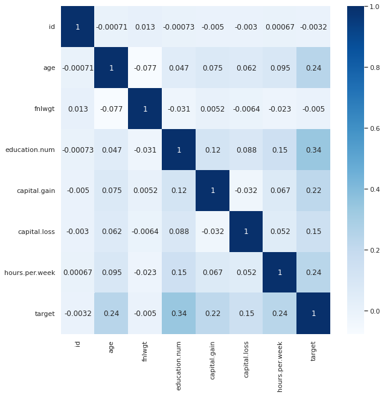

```python
sns.heatmap(corr_matrix, cmap='Blues',annot=True)
sns.set(rc = {'figure.figsize':(10,10)})
```

상관관계 분석 결과 target과 관계성이 높은 변수는 education.num, hours.per.week, age 관계성이 낮은 변수는 fnlwgt, race, native.country임을 알 수 있다.

### 필요없는 변수 제거

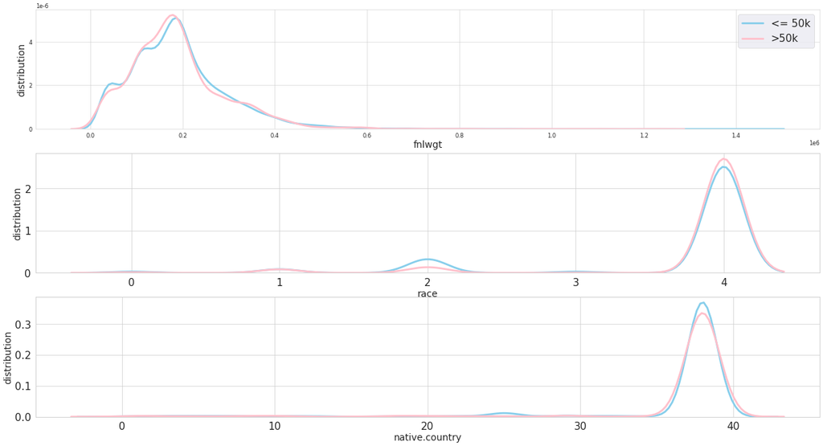

```python
plt.figure(figsize=(30,16),dpi=50)
sns.set_style("whitegrid")

# income 별 fnlwgt 분포
plt.subplot(311)
fnlwgt_0 = train.loc[train['target'] == 0, 'fnlwgt']
fnlwgt_1 = train.loc[train['target'] == 1, 'fnlwgt']
sns.set(font_scale = 2)
sb = sns.distplot(fnlwgt_0, hist = False, kde_kws={"color": "skyblue", "lw": 4})
pn = sns.distplot(fnlwgt_1, hist = False, kde_kws={"color": "pink", "lw": 4})
sb.set_xlabel("fnlwgt", fontsize = 20)
pn.set_ylabel("distribution", fontsize = 20)
plt.legend(labels=["<= 50k",">50k"])

sns.set_style("whitegrid")
# income 별 race 분포
plt.subplot(312)
race_0 = train_label_encoder.loc[train['target'] == 0, 'race']
race_1 = train_label_encoder.loc[train['target'] == 1, 'race']
sns.set(font_scale = 2)
sb = sns.distplot(race_0, hist = False, kde_kws={"color": "skyblue", "lw": 4})
pn = sns.distplot(race_1, hist = False, kde_kws={"color": "pink", "lw": 4})
sb.set_xlabel("race", fontsize = 20)
pn.set_ylabel("distribution", fontsize = 20)

sns.set_style("whitegrid")
# income 별 native.country 분포
plt.subplot(313)
native_country_0 = train_label_encoder.loc[train['target'] == 0, 'native.country']
native_country_1 = train_label_encoder.loc[train['target'] == 1, 'native.country']
sns.set(font_scale = 2)
sb = sns.distplot(native_country_0, hist = False, kde_kws={"color": "skyblue", "lw": 4})
pn = sns.distplot(native_country_1, hist = False, kde_kws={"color": "pink", "lw": 4})
sb.set_xlabel("native.country", fontsize = 20)
pn.set_ylabel("distribution", fontsize = 20)
```

```python
del train['fnlwgt']
del train['race']
del train['native.country']

del test['fnlwgt']
del test['race']
del test['native.country']
```

```python
train
```

|  | id | age | workclass | education.num | marital.status | occupation | relationship | sex | capital.gain | capital.loss | hours.per.week | target |
| --- | --- | --- | --- | --- | --- | --- | --- | --- | --- | --- | --- | --- |
| 0 | 0 | 32 | Private | 12 | Married-civ-spouse | Craft-repair | Husband | Male | 0 | 0 | 40 | 0 |
| 1 | 1 | 33 | Private | 10 | Married-civ-spouse | Exec-managerial | Husband | Male | 0 | 0 | 40 | 1 |
| 2 | 2 | 46 | Private | 10 | Married-civ-spouse | Craft-repair | Husband | Male | 0 | 0 | 40 | 0 |
| 3 | 3 | 23 | Private | 13 | Never-married | Adm-clerical | Own-child | Female | 0 | 0 | 30 | 0 |
| 4 | 4 | 55 | Private | 9 | Divorced | Adm-clerical | Not-in-family | Female | 0 | 0 | 40 | 0 |
| ... | ... | ... | ... | ... | ... | ... | ... | ... | ... | ... | ... | ... |
| 15076 | 15076 | 35 | Private | 14 | Never-married | Exec-managerial | Not-in-family | Male | 0 | 0 | 40 | 0 |
| 15077 | 15077 | 36 | Private | 10 | Divorced | Adm-clerical | Not-in-family | Male | 0 | 0 | 45 | 0 |
| 15078 | 15078 | 50 | Self-emp-inc | 15 | Married-civ-spouse | Prof-specialty | Husband | Male | 0 | 0 | 45 | 1 |
| 15079 | 15079 | 39 | Private | 10 | Divorced | Tech-support | Not-in-family | Female | 0 | 0 | 40 | 0 |
| 15080 | 15080 | 33 | Private | 12 | Married-civ-spouse | Prof-specialty | Husband | Male | 0 | 0 | 50 | 0 |

15081 rows × 12 columns

## 수치형 변수 `age`, `education.num`, `capital.gain`, `capital.loss`, `hours.per.week`, `sex`

```python
target_0 = train.query('target==0').copy()
target_0
```

|  | id | age | workclass | education.num | marital.status | occupation | relationship | sex | capital.gain | capital.loss | hours.per.week | target |
| --- | --- | --- | --- | --- | --- | --- | --- | --- | --- | --- | --- | --- |
| 0 | 0 | 32 | Private | 12 | Married-civ-spouse | Craft-repair | Husband | Male | 0 | 0 | 40 | 0 |
| 2 | 2 | 46 | Private | 10 | Married-civ-spouse | Craft-repair | Husband | Male | 0 | 0 | 40 | 0 |
| 3 | 3 | 23 | Private | 13 | Never-married | Adm-clerical | Own-child | Female | 0 | 0 | 30 | 0 |
| 4 | 4 | 55 | Private | 9 | Divorced | Adm-clerical | Not-in-family | Female | 0 | 0 | 40 | 0 |
| 5 | 5 | 33 | Private | 13 | Married-civ-spouse | Prof-specialty | Husband | Male | 0 | 0 | 40 | 0 |
| ... | ... | ... | ... | ... | ... | ... | ... | ... | ... | ... | ... | ... |
| 15075 | 15075 | 18 | Private | 9 | Never-married | Machine-op-inspct | Not-in-family | Male | 0 | 0 | 37 | 0 |
| 15076 | 15076 | 35 | Private | 14 | Never-married | Exec-managerial | Not-in-family | Male | 0 | 0 | 40 | 0 |
| 15077 | 15077 | 36 | Private | 10 | Divorced | Adm-clerical | Not-in-family | Male | 0 | 0 | 45 | 0 |
| 15079 | 15079 | 39 | Private | 10 | Divorced | Tech-support | Not-in-family | Female | 0 | 0 | 40 | 0 |
| 15080 | 15080 | 33 | Private | 12 | Married-civ-spouse | Prof-specialty | Husband | Male | 0 | 0 | 50 | 0 |

11308 rows × 12 columns

```python
target_1 = train.query('target==1').copy()
target_1
```

|  | id | age | workclass | education.num | marital.status | occupation | relationship | sex | capital.gain | capital.loss | hours.per.week | target |
| --- | --- | --- | --- | --- | --- | --- | --- | --- | --- | --- | --- | --- |
| 1 | 1 | 33 | Private | 10 | Married-civ-spouse | Exec-managerial | Husband | Male | 0 | 0 | 40 | 1 |
| 6 | 6 | 40 | State-gov | 15 | Married-civ-spouse | Prof-specialty | Husband | Male | 0 | 0 | 38 | 1 |
| 13 | 13 | 51 | Private | 7 | Married-civ-spouse | Craft-repair | Husband | Male | 0 | 0 | 40 | 1 |
| 18 | 18 | 27 | Private | 10 | Married-civ-spouse | Prof-specialty | Husband | Male | 0 | 0 | 40 | 1 |
| 21 | 21 | 58 | Private | 10 | Married-civ-spouse | Sales | Husband | Male | 0 | 0 | 45 | 1 |
| ... | ... | ... | ... | ... | ... | ... | ... | ... | ... | ... | ... | ... |
| 15069 | 15069 | 42 | Federal-gov | 11 | Divorced | Adm-clerical | Unmarried | Female | 0 | 0 | 40 | 1 |
| 15070 | 15070 | 41 | Private | 10 | Married-civ-spouse | Craft-repair | Husband | Male | 7298 | 0 | 50 | 1 |
| 15072 | 15072 | 61 | Private | 13 | Divorced | Adm-clerical | Not-in-family | Male | 0 | 0 | 40 | 1 |
| 15073 | 15073 | 57 | Self-emp-not-inc | 10 | Married-civ-spouse | Transport-moving | Husband | Male | 0 | 0 | 45 | 1 |
| 15078 | 15078 | 50 | Self-emp-inc | 15 | Married-civ-spouse | Prof-specialty | Husband | Male | 0 | 0 | 45 | 1 |

3773 rows × 12 columns

### age

age min = 17 age max = 90

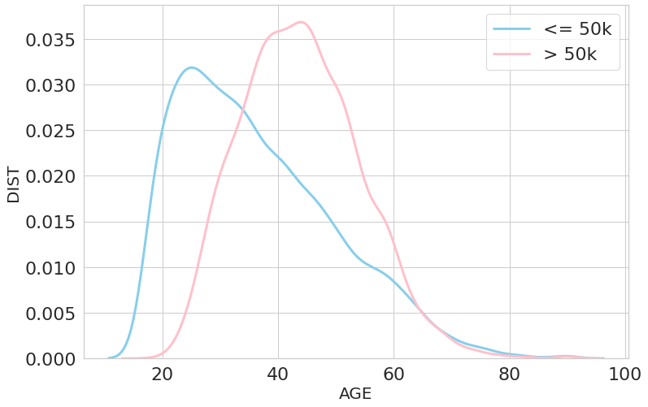

```python
age_0 = target_0['age']
age_1 = target_1['age']

sns.set(font_scale = 2)
plt.figure(figsize=(12,8))
sns.set_style('whitegrid')
ax_0 = sns.distplot(age_0, hist = False, kde_kws={"color": "skyblue", "lw": 3})
ax_1 = sns.distplot(age_1, hist = False, kde_kws={"color": "pink", "lw": 3})
ax_0.set_xlabel("AGE", fontsize = 20)
ax_0.set_ylabel("DIST", fontsize = 20)
plt.legend(labels=["<= 50k","> 50k"])
```

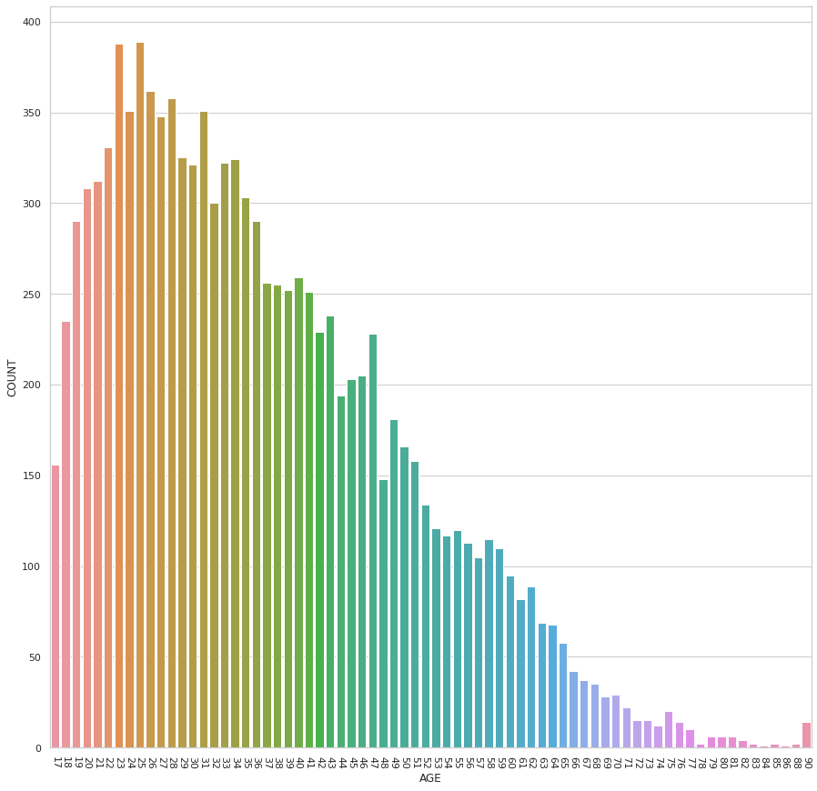

```python
# target_0데이터 age변수의 count를 시각화해준다.
sns.set_style("whitegrid") # 그래프의 배경을 whitegrid로 지정해준다.
ax = sns.countplot(x=target_0['age'], data=target_0)
ax.set(xlabel="AGE", ylabel = "COUNT") # xlabel = AGE, ylabel = COUNT로 지정해준다.
plt.xticks(rotation = - 90 )
sns.set(rc = {'figure.figsize':(15,15)})
plt.show()
```

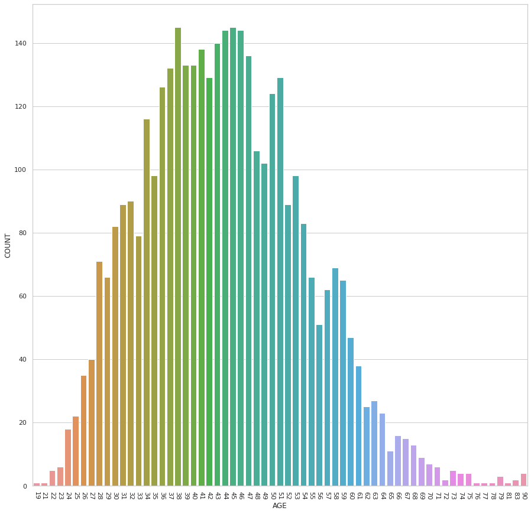

```python
sns.set_style("whitegrid") # 그래프의 배경을 whitegrid로 지정해준다.
ax = sns.countplot(x=target_1['age'], data=target_1)
ax.set(xlabel="AGE", ylabel = "COUNT") # xlabel = AGE, ylabel = COUNT로 지정해준다.
plt.xticks(rotation = - 90 )
sns.set(rc = {'figure.figsize':(15,15)})
plt.show()
```

분포가 너무 많아 시각화로 보기 힘들 것 같아 적당한 구간을 나누어 ppt 차트에 값을 입력해주었다.

### education.num

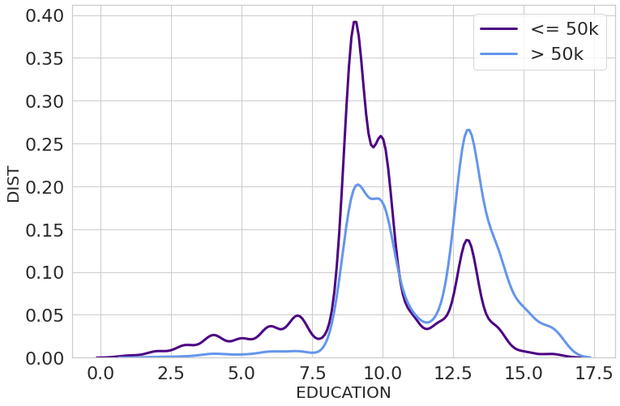

```python
education_0 = target_0['education.num']
education_1 = target_1['education.num']

sns.set(font_scale = 2)
plt.figure(figsize=(12,8))
sns.set_style('whitegrid')
ax_0 = sns.distplot(education_0, hist = False, kde_kws={"color": "indigo", "lw": 3})
ax_1 = sns.distplot(education_1, hist = False, kde_kws={"color": "cornflowerblue", "lw": 3})
ax_0.set_xlabel("EDUCATION", fontsize = 20)
ax_0.set_ylabel("DIST", fontsize = 20)
plt.legend(labels=["<= 50k","> 50k"])
```

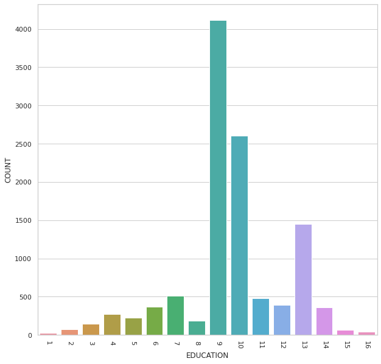

```python
sns.set_style("whitegrid") # 그래프의 배경을 whitegrid로 지정해준다.
ax = sns.countplot(x=target_0['education.num'], data=target_0)
ax.set(xlabel="EDUCATION", ylabel = "COUNT") # xlabe = EDUCATION, ylabel = COUNT로 지정해준다.
plt.xticks(rotation = - 90 )
sns.set(rc = {'figure.figsize':(10,10)})
plt.show()
```

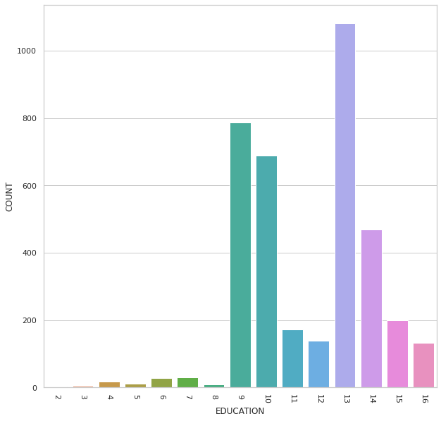

```python
sns.set_style("whitegrid")
ax = sns.countplot(x=target_1['education.num'], data=target_1)
ax.set(xlabel="EDUCATION", ylabel = "COUNT")
plt.xticks(rotation = - 90 )
sns.set(rc = {'figure.figsize':(10,10)})
plt.show()
```

### capital.gain

```python
train['capital.gain'].value_counts()
```

```
0        13812
15024      176
7688       136
7298       116
99999       76
         ...
4687         1
34095        1
1409         1
401          1
1797         1
Name: capital.gain, Length: 107, dtype: int64
```

```python
train['capital.gain']
```

```
0        0
1        0
2        0
3        0
4        0
        ..
15076    0
15077    0
15078    0
15079    0
15080    0
Name: capital.gain, Length: 15081, dtype: int64
```

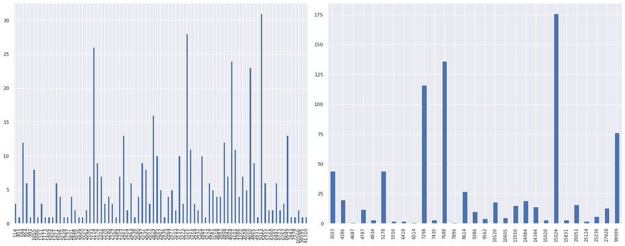

```python
fig, axes = plt.subplots(1, 2)
fig.set_size_inches(20, 8)

gain1 = train.loc[(train['target'] == 0) & (train['capital.gain'] > 0), 'capital.gain'].value_counts().sort_index()

gain1.plot(kind='bar', ax=axes[0])
plt.xticks(fontsize =10)

gain1 = train.loc[(train['target'] == 1) & (train['capital.gain'] > 0), 'capital.gain'].value_counts().sort_index()
gain1.plot(kind='bar', ax=axes[1])

plt.tight_layout()
plt.show()
```

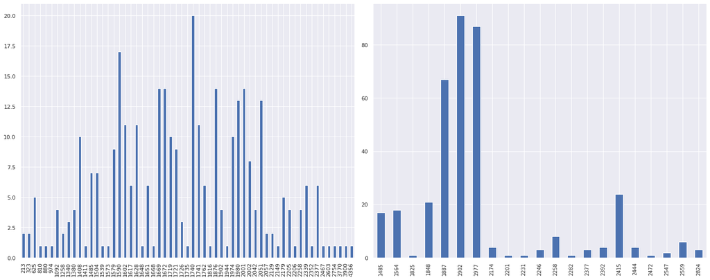

```python
fig, axes = plt.subplots(1, 2)
fig.set_size_inches(20, 8)
loss1 = train.loc[(train['target'] == 0) & (train['capital.loss'] > 0), 'capital.loss'].value_counts().sort_index()
loss1.plot(kind='bar', ax=axes[0])

plt.xticks(fontsize =10)

loss1 = train.loc[(train['target'] == 1) & (train['capital.loss'] > 0), 'capital.loss'].value_counts().sort_index()
loss1.plot(kind='bar', ax=axes[1])

plt.tight_layout()
plt.show()
```

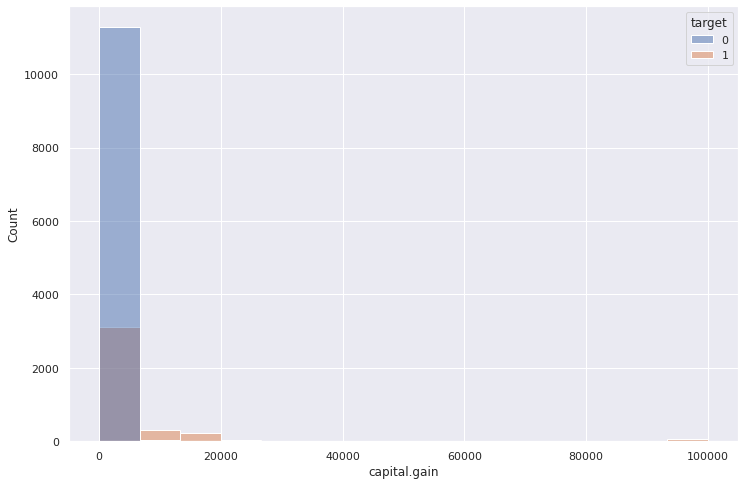

```python
plt.figure(figsize=(12,8))
sns.histplot(x='capital.gain',hue='target',data=train)
```

### capital.loss

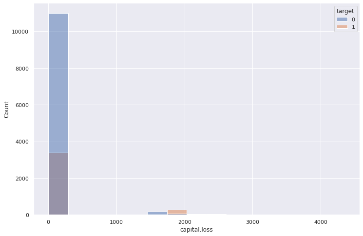

```python
plt.figure(figsize=(12,8))
sns.histplot(x='capital.loss',hue='target',data=train)
```

capital.gain 변수와 capital.loss 변수를 다양하게 시각화 해보았으나 값들이 무엇을 의미하는지 알 수 없어서 아쉬웠다.

### hours.per.week

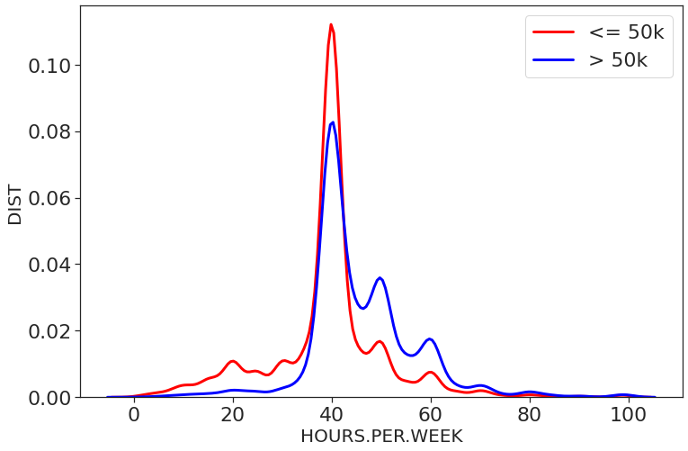

```python
hours_per_week_0 = target_0['hours.per.week']
hours_per_week_1 = target_1['hours.per.week']

sns.set(font_scale = 2)
plt.figure(figsize=(12,8))
sns.set_style('ticks')
ax_0 = sns.distplot(hours_per_week_0, hist = False, kde_kws={"color": "red", "lw": 3})
ax_1 = sns.distplot(hours_per_week_1, hist = False, kde_kws={"color": "blue", "lw": 3})
ax_0.set_xlabel("HOURS.PER.WEEK", fontsize = 20)
ax_0.set_ylabel("DIST", fontsize = 20)
plt.legend(labels=["<= 50k","> 50k"])
```

```python
target_0['hours.per.week'].value_counts()
```

```
40    5634
50     721
35     540
45     527
20     495
      ...
82       1
92       1
94       1
88       1
74       1
Name: hours.per.week, Length: 86, dtype: int64
```

```python
 def hours_per_week(a):
    if a <= 10:
        score = '10시간 이하'
    elif a <= 20:
        score = '20시간 이하'
    elif a <= 30:
        score = '30시간 이하'
    elif a <= 40:
        score = '40시간 이하'
    elif a <= 50:
        score = '50시간 이하'
    elif a <= 60:
        score = '60시간 이하'
    elif a <= 70:
        score = '70시간 이하'
    elif a <= 80:
        score = '80시간 이하'
    else:
        score = '81시간 이상'
    return score
```

```python
target_0["주당근무시간"] = target_0["hours.per.week"].apply(lambda a: hours_per_week(a))
target_1["주당근무시간"] = target_1["hours.per.week"].apply(lambda a: hours_per_week(a))
```

```python
target_0
```

|  | id | age | workclass | education.num | marital.status | occupation | relationship | sex | capital.gain | capital.loss | hours.per.week | target | 주당근무시간 |
| --- | --- | --- | --- | --- | --- | --- | --- | --- | --- | --- | --- | --- | --- |
| 0 | 0 | 32 | Private | 12 | Married-civ-spouse | Craft-repair | Husband | Male | 0 | 0 | 40 | 0 | 40시간 이하 |
| 2 | 2 | 46 | Private | 10 | Married-civ-spouse | Craft-repair | Husband | Male | 0 | 0 | 40 | 0 | 40시간 이하 |
| 3 | 3 | 23 | Private | 13 | Never-married | Adm-clerical | Own-child | Female | 0 | 0 | 30 | 0 | 30시간 이하 |
| 4 | 4 | 55 | Private | 9 | Divorced | Adm-clerical | Not-in-family | Female | 0 | 0 | 40 | 0 | 40시간 이하 |
| 5 | 5 | 33 | Private | 13 | Married-civ-spouse | Prof-specialty | Husband | Male | 0 | 0 | 40 | 0 | 40시간 이하 |
| ... | ... | ... | ... | ... | ... | ... | ... | ... | ... | ... | ... | ... | ... |
| 15075 | 15075 | 18 | Private | 9 | Never-married | Machine-op-inspct | Not-in-family | Male | 0 | 0 | 37 | 0 | 40시간 이하 |
| 15076 | 15076 | 35 | Private | 14 | Never-married | Exec-managerial | Not-in-family | Male | 0 | 0 | 40 | 0 | 40시간 이하 |
| 15077 | 15077 | 36 | Private | 10 | Divorced | Adm-clerical | Not-in-family | Male | 0 | 0 | 45 | 0 | 50시간 이하 |
| 15079 | 15079 | 39 | Private | 10 | Divorced | Tech-support | Not-in-family | Female | 0 | 0 | 40 | 0 | 40시간 이하 |
| 15080 | 15080 | 33 | Private | 12 | Married-civ-spouse | Prof-specialty | Husband | Male | 0 | 0 | 50 | 0 | 50시간 이하 |

11308 rows × 13 columns

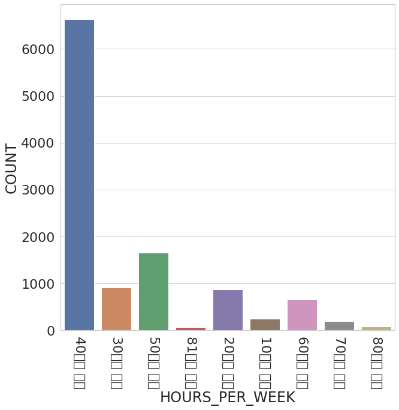

```python
sns.set_style("whitegrid")
ax = sns.countplot(x=target_0['주당근무시간'], data=target_0)
ax.set(xlabel="HOURS_PER_WEEK", ylabel = "COUNT")
plt.xticks(rotation = - 90 )
sns.set(rc = {'figure.figsize':(10,10)})
# plt.rcParams['font.family'] = 'Malgun Gothic'
plt.rc('font', family='Malgun Gothic')
plt.show()
```

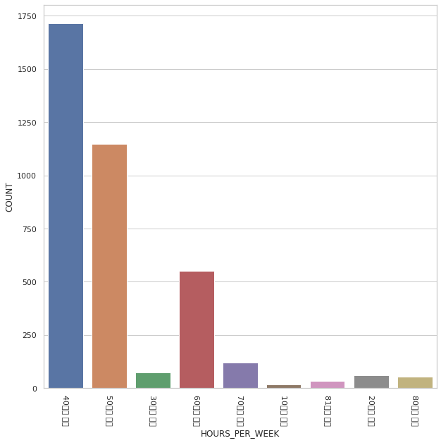

```python
sns.set_style("whitegrid")
ax = sns.countplot(x=target_1['주당근무시간'], data=target_1)
ax.set(xlabel="HOURS_PER_WEEK", ylabel = "COUNT")
plt.xticks(rotation = - 90 )
sns.set(rc = {'figure.figsize':(10,10)})
plt.rcParams['font.family'] = 'Malgun Gothic'
plt.show()
```

ppt 시각화를 위해 분포하는 정확한 값들을 뽑아 ppt 차트에 적용하여주었다.

```python
target_0['주당근무시간'].value_counts()
```

```
40시간 이하    6627
50시간 이하    1659
30시간 이하     917
20시간 이하     876
60시간 이하     654
10시간 이하     242
70시간 이하     189
80시간 이하      75
81시간 이상      69
Name: 주당근무시간, dtype: int64
```

```python
target_1['주당근무시간'].value_counts()
```

```
40시간 이하    1716
50시간 이하    1149
60시간 이하     551
70시간 이하     120
30시간 이하      73
20시간 이하      61
80시간 이하      53
81시간 이상      34
10시간 이하      16
Name: 주당근무시간, dtype: int64
```

### sex

```python
train['sex'] = le.fit_transform(train['sex'])
test['sex'] = le.fit_transform(test['sex'])
target_0['sex'] = le.fit_transform(target_0['sex'])
target_1['sex'] = le.fit_transform(target_1['sex'])
```

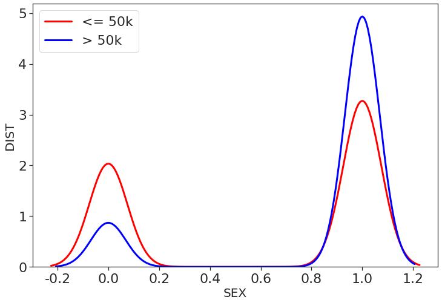

```python
sex_0 = target_0['sex']
sex_1 = target_1['sex']

sns.set(font_scale = 2)
plt.figure(figsize=(12,8))
sns.set_style('ticks')
ax_0 = sns.distplot(sex_0, hist = False, kde_kws={"color": "red", "lw": 3})
ax_1 = sns.distplot(sex_1, hist = False, kde_kws={"color": "blue", "lw": 3})
ax_0.set_xlabel("SEX", fontsize = 20)
ax_0.set_ylabel("DIST", fontsize = 20)
plt.legend(labels=["<= 50k","> 50k"])
```

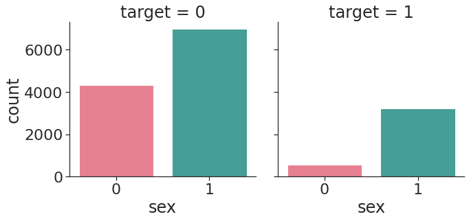

```python
sns.catplot(x="sex", col="target",
                data=train, kind="count",palette="husl")
```

```python
target_0['sex'].value_counts()
```

```
1    6972
0    4336
Name: sex, dtype: int64
```

```python
target_1['sex'].value_counts()
```

```
1    3208
0     565
Name: sex, dtype: int64
```

## 범주형 변수 `workclass`, `marital.status`, `occupation`, `relationship`, `sex`

### 변수 고유값 확인

sex 변수처럼 수치화하여 EDA 해보아도 괜찮을 것 같은 변수를 찾아보기 위해 확인해보았다.

```python
train['workclass'].value_counts()
```

```
Private             11158
Self-emp-not-inc     1230
Local-gov            1027
State-gov             640
Self-emp-inc          552
Federal-gov           468
Without-pay             6
Name: workclass, dtype: int64
```

```python
train['marital.status'].value_counts()
```

```
Married-civ-spouse       7092
Never-married            4814
Divorced                 2086
Separated                 454
Widowed                   424
Married-spouse-absent     199
Married-AF-spouse          12
Name: marital.status, dtype: int64
```

```python
train['occupation'].value_counts()
```

```
Exec-managerial      2039
Craft-repair         2032
Prof-specialty       1983
Adm-clerical         1844
Sales                1763
Other-service        1594
Machine-op-inspct    1004
Transport-moving      760
Handlers-cleaners     675
Farming-fishing       503
Tech-support          459
Protective-serv       345
Priv-house-serv        77
Armed-Forces            3
Name: occupation, dtype: int64
```

```python
train['relationship'].value_counts()
```

```
Husband           6242
Not-in-family     3836
Own-child         2232
Unmarried         1588
Wife               742
Other-relative     441
Name: relationship, dtype: int64
```

```python
train['sex'].value_counts()
```

```
1    10180
0     4901
Name: sex, dtype: int64
```

변수의 분포를 살펴보았지만 sex변수를 제외하고는 범주형으로 시각화를 하는 것이 더 좋겠다고 판단하였다.

### workclass

ppt 시각화를 위한 코드이다. 더 좋은 시각화를 위해 ppt내의 파이차트를 사용하였다.

```python
train.groupby('workclass')['target'].value_counts()
```

```
workclass         target
Federal-gov       0          291
                  1          177
Local-gov         0          718
                  1          309
Private           0         8713
                  1         2445
Self-emp-inc      1          301
                  0          251
Self-emp-not-inc  0          867
                  1          363
State-gov         0          462
                  1          178
Without-pay       0            6
Name: target, dtype: int64
```

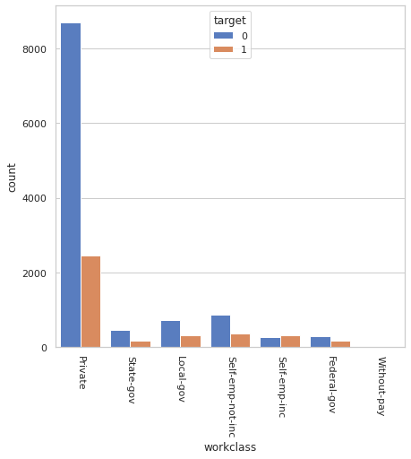

```python
sns.set_style("whitegrid")
sns.countplot(x=train['workclass'], hue = train['target'],palette = "muted")
plt.xticks(rotation = - 90 )
sns.set(rc = {'figure.figsize':(7,7)})
```

### marital.status

```python
train.groupby('marital.status')['target'].value_counts()
```

```
marital.status         target
Divorced               0         1850
                       1          236
Married-AF-spouse      0            7
                       1            5
Married-civ-spouse     0         3885
                       1         3207
Married-spouse-absent  0          183
                       1           16
Never-married          0         4582
                       1          232
Separated              0          420
                       1           34
Widowed                0          381
                       1           43
Name: target, dtype: int64
```

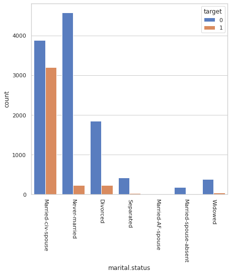

```python
sns.set_style("whitegrid")
sns.countplot(x=train['marital.status'], hue = train['target'],palette = "muted")
plt.xticks(rotation = - 90 )
sns.set(rc = {'figure.figsize':(7,7)})
```

### occupation

```python
train.groupby('occupation')['target'].value_counts()
```

```
occupation         target
Adm-clerical       0         1591
                   1          253
Armed-Forces       0            3
Craft-repair       0         1576
                   1          456
Exec-managerial    0         1047
                   1          992
Farming-fishing    0          438
                   1           65
Handlers-cleaners  0          639
                   1           36
Machine-op-inspct  0          876
                   1          128
Other-service      0         1527
                   1           67
Priv-house-serv    0           77
Prof-specialty     0         1088
                   1          895
Protective-serv    0          233
                   1          112
Sales              0         1280
                   1          483
Tech-support       0          322
                   1          137
Transport-moving   0          611
                   1          149
Name: target, dtype: int64
```

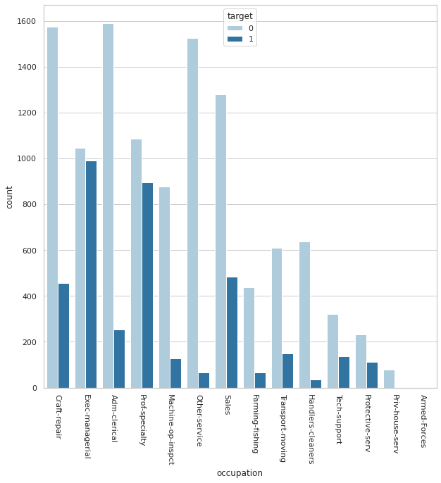

```python
sns.set_style("whitegrid")
sns.countplot(x=train['occupation'], hue = train['target'],palette = "Paired")
plt.xticks(rotation = - 90 )
sns.set(rc = {'figure.figsize':(10,10)})
```

### relationship

```python
train.groupby('relationship')['target'].value_counts()
```

```
relationship    target
Husband         0         3409
                1         2833
Not-in-family   0         3407
                1          429
Other-relative  0          422
                1           19
Own-child       0         2197
                1           35
Unmarried       0         1486
                1          102
Wife            0          387
                1          355
Name: target, dtype: int64
```

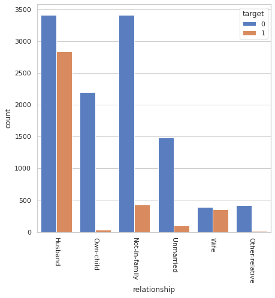

```python
sns.set_style("whitegrid")
sns.countplot(x=train['relationship'], hue = train['target'],palette = "muted")
plt.xticks(rotation = - 90 )
sns.set(rc = {'figure.figsize':(7,7)})
```

# 모델링

## 원핫인코딩

범주형 데이터를 one-hot encoding을 사용하여 범주의 개수만큼 dummy variable을 만들어 0 또는 1을 각 범주마다 할당하여 새로운 특성으로 바꾸는 방법이다.

```python
train_one = pd.get_dummies(train)
train_one.head()
```

|  | id | age | education.num | sex | capital.gain | capital.loss | hours.per.week | target | workclass_Federal-gov | workclass_Local-gov | ... | occupation_Protective-serv | occupation_Sales | occupation_Tech-support | occupation_Transport-moving | relationship_Husband | relationship_Not-in-family | relationship_Other-relative | relationship_Own-child | relationship_Unmarried | relationship_Wife |
| --- | --- | --- | --- | --- | --- | --- | --- | --- | --- | --- | --- | --- | --- | --- | --- | --- | --- | --- | --- | --- | --- |
| 0 | 0 | 32 | 12 | 1 | 0 | 0 | 40 | 0 | 0 | 0 | ... | 0 | 0 | 0 | 0 | 1 | 0 | 0 | 0 | 0 | 0 |
| 1 | 1 | 33 | 10 | 1 | 0 | 0 | 40 | 1 | 0 | 0 | ... | 0 | 0 | 0 | 0 | 1 | 0 | 0 | 0 | 0 | 0 |
| 2 | 2 | 46 | 10 | 1 | 0 | 0 | 40 | 0 | 0 | 0 | ... | 0 | 0 | 0 | 0 | 1 | 0 | 0 | 0 | 0 | 0 |
| 3 | 3 | 23 | 13 | 0 | 0 | 0 | 30 | 0 | 0 | 0 | ... | 0 | 0 | 0 | 0 | 0 | 0 | 0 | 1 | 0 | 0 |
| 4 | 4 | 55 | 9 | 0 | 0 | 0 | 40 | 0 | 0 | 0 | ... | 0 | 0 | 0 | 0 | 0 | 1 | 0 | 0 | 0 | 0 |

5 rows × 42 columns

```python
train
```

|  | id | age | workclass | education.num | marital.status | occupation | relationship | sex | capital.gain | capital.loss | hours.per.week | target |
| --- | --- | --- | --- | --- | --- | --- | --- | --- | --- | --- | --- | --- |
| 0 | 0 | 32 | Private | 12 | Married-civ-spouse | Craft-repair | Husband | 1 | 0 | 0 | 40 | 0 |
| 1 | 1 | 33 | Private | 10 | Married-civ-spouse | Exec-managerial | Husband | 1 | 0 | 0 | 40 | 1 |
| 2 | 2 | 46 | Private | 10 | Married-civ-spouse | Craft-repair | Husband | 1 | 0 | 0 | 40 | 0 |
| 3 | 3 | 23 | Private | 13 | Never-married | Adm-clerical | Own-child | 0 | 0 | 0 | 30 | 0 |
| 4 | 4 | 55 | Private | 9 | Divorced | Adm-clerical | Not-in-family | 0 | 0 | 0 | 40 | 0 |
| ... | ... | ... | ... | ... | ... | ... | ... | ... | ... | ... | ... | ... |
| 15076 | 15076 | 35 | Private | 14 | Never-married | Exec-managerial | Not-in-family | 1 | 0 | 0 | 40 | 0 |
| 15077 | 15077 | 36 | Private | 10 | Divorced | Adm-clerical | Not-in-family | 1 | 0 | 0 | 45 | 0 |
| 15078 | 15078 | 50 | Self-emp-inc | 15 | Married-civ-spouse | Prof-specialty | Husband | 1 | 0 | 0 | 45 | 1 |
| 15079 | 15079 | 39 | Private | 10 | Divorced | Tech-support | Not-in-family | 0 | 0 | 0 | 40 | 0 |
| 15080 | 15080 | 33 | Private | 12 | Married-civ-spouse | Prof-specialty | Husband | 1 | 0 | 0 | 50 | 0 |

15081 rows × 12 columns

```python
test_one = pd.get_dummies(test)
test_one.head()
```

|  | id | age | education.num | sex | capital.gain | capital.loss | hours.per.week | workclass_Federal-gov | workclass_Local-gov | workclass_Private | ... | occupation_Protective-serv | occupation_Sales | occupation_Tech-support | occupation_Transport-moving | relationship_Husband | relationship_Not-in-family | relationship_Other-relative | relationship_Own-child | relationship_Unmarried | relationship_Wife |
| --- | --- | --- | --- | --- | --- | --- | --- | --- | --- | --- | --- | --- | --- | --- | --- | --- | --- | --- | --- | --- | --- |
| 0 | 0 | 47 | 10 | 1 | 0 | 0 | 45 | 0 | 0 | 1 | ... | 0 | 0 | 0 | 0 | 1 | 0 | 0 | 0 | 0 | 0 |
| 1 | 1 | 34 | 10 | 1 | 0 | 0 | 75 | 0 | 0 | 0 | ... | 0 | 1 | 0 | 0 | 0 | 1 | 0 | 0 | 0 | 0 |
| 2 | 2 | 31 | 13 | 1 | 8614 | 0 | 40 | 0 | 1 | 0 | ... | 0 | 0 | 0 | 0 | 0 | 1 | 0 | 0 | 0 | 0 |
| 3 | 3 | 28 | 13 | 1 | 0 | 0 | 55 | 0 | 0 | 1 | ... | 0 | 0 | 0 | 0 | 1 | 0 | 0 | 0 | 0 | 0 |
| 4 | 4 | 54 | 10 | 0 | 0 | 0 | 40 | 0 | 1 | 0 | ... | 0 | 0 | 0 | 0 | 0 | 0 | 0 | 0 | 1 | 0 |

5 rows × 41 columns

```python
test
```

|  | id | age | workclass | education.num | marital.status | occupation | relationship | sex | capital.gain | capital.loss | hours.per.week |
| --- | --- | --- | --- | --- | --- | --- | --- | --- | --- | --- | --- |
| 0 | 0 | 47 | Private | 10 | Married-civ-spouse | Exec-managerial | Husband | 1 | 0 | 0 | 45 |
| 1 | 1 | 34 | Self-emp-inc | 10 | Never-married | Sales | Not-in-family | 1 | 0 | 0 | 75 |
| 2 | 2 | 31 | Local-gov | 13 | Never-married | Craft-repair | Not-in-family | 1 | 8614 | 0 | 40 |
| 3 | 3 | 28 | Private | 13 | Married-civ-spouse | Prof-specialty | Husband | 1 | 0 | 0 | 55 |
| 4 | 4 | 54 | Local-gov | 10 | Widowed | Adm-clerical | Unmarried | 0 | 0 | 0 | 40 |
| ... | ... | ... | ... | ... | ... | ... | ... | ... | ... | ... | ... |
| 15076 | 15076 | 30 | Local-gov | 10 | Married-civ-spouse | Protective-serv | Husband | 1 | 15024 | 0 | 40 |
| 15077 | 15077 | 39 | Private | 13 | Married-civ-spouse | Craft-repair | Husband | 1 | 0 | 0 | 40 |
| 15078 | 15078 | 48 | Private | 7 | Never-married | Machine-op-inspct | Unmarried | 1 | 0 | 0 | 40 |
| 15079 | 15079 | 44 | Private | 9 | Married-civ-spouse | Machine-op-inspct | Husband | 1 | 0 | 0 | 40 |
| 15080 | 15080 | 30 | Private | 9 | Never-married | Craft-repair | Not-in-family | 1 | 0 | 0 | 46 |

15081 rows × 11 columns

## pycaret

```python
from pycaret.classification import *
reg = setup(train_one, target='target')
```

|  | Description | Value |
| --- | --- | --- |
| 0 | session_id | 4081 |
| 1 | Target | target |
| 2 | Target Type | Binary |
| 3 | Label Encoded | None |
| 4 | Original Data | (15081, 42) |
| 5 | Missing Values | False |
| 6 | Numeric Features | 39 |
| 7 | Categorical Features | 2 |
| 8 | Ordinal Features | False |
| 9 | High Cardinality Features | False |
| 10 | High Cardinality Method | None |
| 11 | Transformed Train Set | (10556, 55) |
| 12 | Transformed Test Set | (4525, 55) |
| 13 | Shuffle Train-Test | True |
| 14 | Stratify Train-Test | False |
| 15 | Fold Generator | StratifiedKFold |
| 16 | Fold Number | 10 |
| 17 | CPU Jobs | -1 |
| 18 | Use GPU | False |
| 19 | Log Experiment | False |
| 20 | Experiment Name | clf-default-name |
| 21 | USI | a9a8 |
| 22 | Imputation Type | simple |
| 23 | Iterative Imputation Iteration | None |
| 24 | Numeric Imputer | mean |
| 25 | Iterative Imputation Numeric Model | None |
| 26 | Categorical Imputer | constant |
| 27 | Iterative Imputation Categorical Model | None |
| 28 | Unknown Categoricals Handling | least_frequent |
| 29 | Normalize | False |
| 30 | Normalize Method | None |
| 31 | Transformation | False |
| 32 | Transformation Method | None |
| 33 | PCA | False |
| 34 | PCA Method | None |
| 35 | PCA Components | None |
| 36 | Ignore Low Variance | False |
| 37 | Combine Rare Levels | False |
| 38 | Rare Level Threshold | None |
| 39 | Numeric Binning | False |
| 40 | Remove Outliers | False |
| 41 | Outliers Threshold | None |
| 42 | Remove Multicollinearity | False |
| 43 | Multicollinearity Threshold | None |
| 44 | Remove Perfect Collinearity | True |
| 45 | Clustering | False |
| 46 | Clustering Iteration | None |
| 47 | Polynomial Features | False |
| 48 | Polynomial Degree | None |
| 49 | Trignometry Features | False |
| 50 | Polynomial Threshold | None |
| 51 | Group Features | False |
| 52 | Feature Selection | False |
| 53 | Feature Selection Method | classic |
| 54 | Features Selection Threshold | None |
| 55 | Feature Interaction | False |
| 56 | Feature Ratio | False |
| 57 | Interaction Threshold | None |
| 58 | Fix Imbalance | False |
| 59 | Fix Imbalance Method | SMOTE |

```python
top3 = compare_models(sort = 'Accuracy',n_select = 3)
# top3 = lightgbm, gbc, ada
```

|  | Model | Accuracy | AUC | Recall | Prec. | F1 | Kappa | MCC | TT (Sec) |
| --- | --- | --- | --- | --- | --- | --- | --- | --- | --- |
| lightgbm | Light Gradient Boosting Machine | 0.8644 | 0.9218 | 0.6503 | 0.7659 | 0.7026 | 0.6157 | 0.6196 | 0.166 |
| gbc | Gradient Boosting Classifier | 0.8584 | 0.9149 | 0.5842 | 0.7873 | 0.6699 | 0.5824 | 0.5934 | 1.095 |
| ada | Ada Boost Classifier | 0.8534 | 0.9082 | 0.6118 | 0.7483 | 0.6727 | 0.5795 | 0.5847 | 0.325 |
| lr | Logistic Regression | 0.8435 | 0.9009 | 0.5903 | 0.7247 | 0.6502 | 0.5508 | 0.5559 | 1.426 |
| rf | Random Forest Classifier | 0.8396 | 0.8861 | 0.6153 | 0.6989 | 0.6541 | 0.5503 | 0.5524 | 1.002 |
| lda | Linear Discriminant Analysis | 0.8354 | 0.8910 | 0.5576 | 0.7122 | 0.6251 | 0.5217 | 0.5283 | 0.100 |
| ridge | Ridge Classifier | 0.8326 | 0.0000 | 0.5042 | 0.7339 | 0.5970 | 0.4961 | 0.5104 | 0.022 |
| knn | K Neighbors Classifier | 0.8309 | 0.8588 | 0.6184 | 0.6707 | 0.6431 | 0.5326 | 0.5336 | 0.513 |
| et | Extra Trees Classifier | 0.8186 | 0.8432 | 0.5841 | 0.6465 | 0.6134 | 0.4954 | 0.4967 | 1.088 |
| dt | Decision Tree Classifier | 0.8109 | 0.7537 | 0.5999 | 0.6209 | 0.6100 | 0.4853 | 0.4856 | 0.054 |
| nb | Naive Bayes | 0.8058 | 0.8889 | 0.7894 | 0.5780 | 0.6671 | 0.5347 | 0.5478 | 0.024 |
| svm | SVM - Linear Kernel | 0.7873 | 0.0000 | 0.5359 | 0.5944 | 0.5346 | 0.4051 | 0.4228 | 0.051 |
| dummy | Dummy Classifier | 0.7535 | 0.5000 | 0.0000 | 0.0000 | 0.0000 | 0.0000 | 0.0000 | 0.017 |
| qda | Quadratic Discriminant Analysis | 0.2540 | 0.5050 | 1.0000 | 0.2484 | 0.3979 | 0.0049 | 0.0487 | 0.051 |

```python
tuned_top3 = [tune_model(i) for i in top3]
```

| Fold | Accuracy | AUC | Recall | Prec. | F1 | Kappa | MCC |
| --- | --- | --- | --- | --- | --- | --- | --- |
| 0 | 0.8466 | 0.9005 | 0.6231 | 0.7168 | 0.6667 | 0.5677 | 0.5700 |
| 1 | 0.8580 | 0.9193 | 0.6385 | 0.7477 | 0.6888 | 0.5975 | 0.6006 |
| 2 | 0.8494 | 0.9004 | 0.5885 | 0.7463 | 0.6581 | 0.5633 | 0.5698 |
| 3 | 0.8665 | 0.9235 | 0.6192 | 0.7931 | 0.6955 | 0.6116 | 0.6193 |
| 4 | 0.8608 | 0.9204 | 0.6015 | 0.7850 | 0.6811 | 0.5941 | 0.6027 |
| 5 | 0.8608 | 0.9281 | 0.6130 | 0.7767 | 0.6852 | 0.5974 | 0.6043 |
| 6 | 0.8597 | 0.9185 | 0.6154 | 0.7692 | 0.6838 | 0.5951 | 0.6012 |
| 7 | 0.8654 | 0.9226 | 0.6308 | 0.7810 | 0.6979 | 0.6125 | 0.6183 |
| 8 | 0.8692 | 0.9151 | 0.5962 | 0.8245 | 0.6920 | 0.6116 | 0.6246 |
| 9 | 0.8635 | 0.9119 | 0.6269 | 0.7762 | 0.6936 | 0.6071 | 0.6128 |
| Mean | 0.8600 | 0.9160 | 0.6153 | 0.7717 | 0.6843 | 0.5958 | 0.6024 |
| Std | 0.0068 | 0.0088 | 0.0151 | 0.0279 | 0.0122 | 0.0166 | 0.0181 |

```python
blender_top3 = blend_models(estimator_list=tuned_top3)
```

| Fold | Accuracy | AUC | Recall | Prec. | F1 | Kappa | MCC |
| --- | --- | --- | --- | --- | --- | --- | --- |
| 0 | 0.8513 | 0.9015 | 0.6385 | 0.7249 | 0.6789 | 0.5827 | 0.5847 |
| 1 | 0.8703 | 0.9218 | 0.6577 | 0.7808 | 0.7140 | 0.6309 | 0.6348 |
| 2 | 0.8513 | 0.9025 | 0.5962 | 0.7488 | 0.6638 | 0.5699 | 0.5760 |
| 3 | 0.8665 | 0.9260 | 0.6269 | 0.7874 | 0.6981 | 0.6138 | 0.6203 |
| 4 | 0.8655 | 0.9244 | 0.6130 | 0.7960 | 0.6926 | 0.6084 | 0.6169 |
| 5 | 0.8598 | 0.9304 | 0.6169 | 0.7703 | 0.6851 | 0.5964 | 0.6025 |
| 6 | 0.8578 | 0.9201 | 0.6115 | 0.7644 | 0.6795 | 0.5896 | 0.5956 |
| 7 | 0.8635 | 0.9242 | 0.6192 | 0.7816 | 0.6910 | 0.6049 | 0.6117 |
| 8 | 0.8635 | 0.9182 | 0.5692 | 0.8222 | 0.6727 | 0.5901 | 0.6060 |
| 9 | 0.8626 | 0.9197 | 0.6231 | 0.7751 | 0.6908 | 0.6038 | 0.6098 |
| Mean | 0.8612 | 0.9189 | 0.6172 | 0.7752 | 0.6867 | 0.5990 | 0.6058 |
| Std | 0.0059 | 0.0091 | 0.0224 | 0.0250 | 0.0133 | 0.0163 | 0.0163 |

```python
final_model = finalize_model(blender_top3)
prediction = predict_model(final_model, data=test_one)
```

```python
prediction.rename(columns = {"Label": "target"}, inplace = True)
```

## submission

```python
submission['target'] = prediction['target']
```

```python
submission.to_csv('소득예측.csv', index = False)
```

# 결론

결론 요약(summary), 시사점, 활용가능, 한계, 향휴계획등등

### summary

데이터 전처리 과정에서 : 총 4,262개의 결측치를 발견 및 제거해주었고, 교육수준 변수를 하나 제거해주었다.

EDA 과정에서 세 개의 변수들을 제거해주었고, TARGET값이 0인 그룹과 1인 그룹으로 비교하여 시각화를 진행하였다.  
다양한 변수들이 TARGET값에 따라 많은 차이가 있다는 것을 시각화로 알 수 있었지만 capital.gain과 capital.loss 변수에 대해서는 잘 분석하지 못한 점이 아쉬웠다.

### 활용가능

대회의 목적처럼 앞으로도 다양한 인구데이터를 기반으로 꽤 높은 정확도로 소득을 예측하는 것이 가능할 것 같다.

### 한계

EDA 과정에서 변수들에 대해 모든 분석 및 해석을 하지 못한 점이 아쉽다.

모델링 과정에서는 basic 공모전인만큼 직접 모델 선정 및 모델링까지 진행해보고 싶었으나 파이썬 라이브러리인 pycaret을 이용하여 모델 선정과 모델링을 진행한 점이 아쉽다.

### 향후계획

머신러닝에 대한 공부를 더 한 뒤에 다음 번 머신러닝 관련 공모전에서는 직접 모델 선정을 해보는 것이 목표이다. 또, 작년 머신러닝 수업 때 조별로 진행했던 프로젝트 퀄리티만큼 스스로 해 보는 것이 목표이다.